# Final Project: World Happiness Index

## Data Visualization

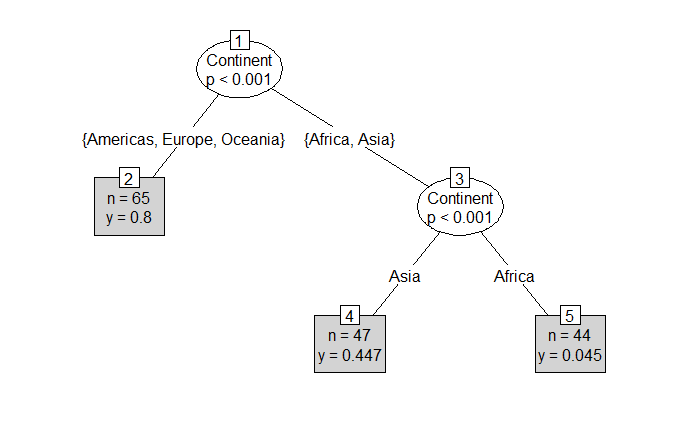

```r
# First, let's plot the decision tree we created earlier.
plot(happy_continents2018, type = "simple")
```

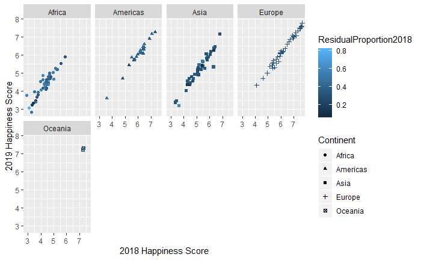

```r
# Before we start mapping, I want to make a scatterplot of happy countries as a function of continent. We saw some clear grouping in our data wrangling phase, but let's visualize what we learned before tackling something more complicated.
Happiness <- Happiness %>% mutate(ResidualProportion2018 = Residual.x/Score.x)
Happiness %>% na.omit() %>% ggplot(aes(x = Score.x, y=Score.y)) + geom_point() + aes(colour = ResidualProportion2018, shape = Continent) + facet_wrap(~Continent,ncol=4) + xlab("2018 Happiness Score") + ylab("2019 Happiness Score")
```

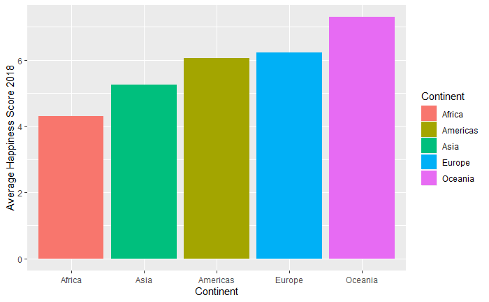

```r
# Now that we've seen the individual data points for the countries, let's use a bar graph to easily compare the average happiness scores for each continent.
ContinentData <- Happiness %>% na.omit() %>% group_by(Continent) %>% summarise(happycontinent2019 = mean(Score.x))
ggplot(data = ContinentData, aes(x = reorder(Continent, happycontinent2019), y = happycontinent2019, fill = Continent)) + geom_bar(stat = 'identity', position = 'stack', width = .9) + xlab("Continent") + ylab("Average Happiness Score 2018")
```

This bar graph gives us an easy visualization of the average happiness for each overall continent, while the scatterplot gave us a better understanding of each country’s happiness within a continent.

```
Mapping API still under development and may change in future releases.
3 items were not translated
```

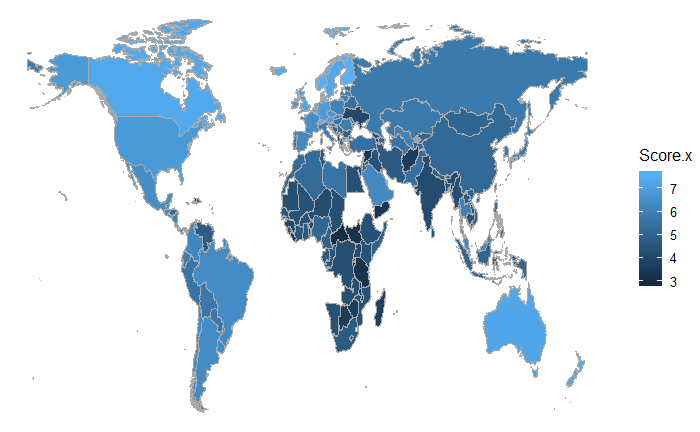

```r
# Finally, let's create a choropleth map of our data.
Happiness %>% na.omit() %>% WorldMap(key = Country.or.region, fill = Score.x)
```

```
Mapping API still under development and may change in future releases.
3 items were not translated
```

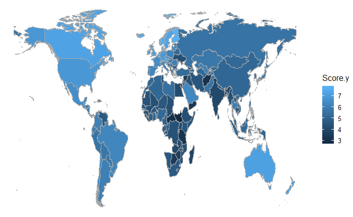

```r
# Next, 2019 data:
Happiness %>% na.omit() %>% WorldMap(key = Country.or.region, fill = Score.y)
```

Looking at these maps allows us to graphically present the answer to my overarching research question. We have done the wrangling, and here is what we’ve learned: now, let’s show which continents are happiest with a number of visualizations so the next researcher doesn’t have to complete the same wrangling tasks. The Americas, Europe, and Oceania are the happiest continents, and Africa is the unhappiest continent.

The guiding questions of this project all contributed to a better understanding of who is happiest in this world and why this is the case. In addition to achieving the overall goal of understanding which continent is the happiest, we also computed a residual value: a type of happiness that we can’t understand with data analysis just yet. We also explored which countries experienced significant social change between 2018 and 2019, identifying those who experienced a notable shift in happiness. In a world connected by constant data mining and research, I wanted to investigate the question of who truly perceives themselves as the happiest, as well as identify what sources and changes in happiness weren’t explained by this Westernized dataset.

The greatest challenge I faced in this project was determining how to create an effective map of the data. I could not use a leaflet map because, unless I assigned a specific point in each country, I did not have longitude and latitude data sufficient to indicate an entire country. I considered using rworldmap or another package, and it wasn’t until I reviewed an old homework assignment that I recalled the effortless WorldMap() option in ggplot2 from the DataComputing package. For purposes of my assignment, I decided this was entirely sufficient to communicate my results. While another method might have been more “impressive” in my data manipulation to a grader, it would’ve yielded the exact same map at the end of the day, just with more work for me and more for the grader to read. I’m currently taking an ArcGIS course on geospatial technology and making great maps, and a key lesson we’ve learned from that course is to get your map’s message across as clearly as possible.

## Links to Data Sources

https://worldhappiness.report/ for the history of the project and appendices describing statistical measures taken. https://www.kaggle.com/unsdsn/world-happiness for a general summary of each factor and downloadable data for each year. https://cran.r-project.org/web/packages/countrycode/countrycode.pdf for documentation on the countrycode R package and how it can be used. https://www.r-spatial.org/r/2018/10/25/ggplot2-sf.html for documentation on how to use ggplot2 and the world map function.